# 淘宝用户行为数据分析报告

袁启航

2022-09-08

## 1. 数据简介

UserBehavior是阿里巴巴提供的一个淘宝用户行为数据集，包含1亿+行数据，用于隐式反馈推荐问题的研究，数据来源为[阿里天池](https://tianchi.aliyun.com)。

本数据集包含了2017年11月25日至2017年12月3日之间，约一百万随机用户的所有行为（包括点击、购买、加购、喜欢）。每一行表示一条用户行为，由用户ID、商品ID、商品类目ID、行为类型和时间戳组成，并以逗号分隔。数据集中每一列的详细描述如下：

| 列名 | 说明 |
| --- | --- |
| 用户ID | 整数类型，序列化后的用户ID |
| 商品ID | 整数类型，序列化后的商品ID |
| 商品类目ID | 整数类型，序列化后的商品所属类目ID |
| 行为类型 | 字符串，枚举类型，包括(‘pv’, ‘buy’, ‘cart’, ‘fav’) |
| 时间戳 | 行为发生的时间戳 |

用户行为类型共有四种，它们分别是:

| 行为类型 | 说明 |
| --- | --- |
| pv | 商品详情页pv，等价于点击 |
| buy | 商品购买 |
| cart | 将商品加入购物车 |
| fav | 收藏商品 |

## 2. 数据导入和清洗

### 2.1 导入数据

由于数据集很大，我们采用data.table提供的方式导入数据。

> data.table是data.frame的高性能版本，基于优秀的内存管理、并行化，让个人电脑都能轻松处理几G甚至几十G的数据[^1],速度远超dplyr、pandas [^2]。

原始数据共有100150807 行，5 列，简单看一下：

| V1 | V2 | V3 | V4 | V5 |
| --- | --- | --- | --- | --- |
| 1 | 2268318 | 2520377 | pv | 1511544070 |
| 1 | 2333346 | 2520771 | pv | 1511561733 |
| 1 | 2576651 | 149192 | pv | 1511572885 |
| 1 | 3830808 | 4181361 | pv | 1511593493 |
| 1 | 4365585 | 2520377 | pv | 1511596146 |
| 1 | 4606018 | 2735466 | pv | 1511616481 |

### 2.2 数据清洗

```
           user_id goods_id goods_type user_action       time
        1:       1  2268318    2520377          pv 1511544070
        2:       1  2333346    2520771          pv 1511561733
        3:       1  2576651     149192          pv 1511572885
        4:       1  3830808    4181361          pv 1511593493
        5:       1  4365585    2520377          pv 1511596146
       ---
100150803:  999999  4797808      11120          pv 1512293403
100150804:  999999  4613472    4602841          pv 1512293766
100150805:  999999  3647364    2304296          pv 1512293792
100150806:  999999  1903801    2304296          pv 1512293827
100150807:  999999  3696094    4602841          pv 1512293891
           user_id goods_id goods_type user_action       time
        1:       1  2268318    2520377          pv 1511544070
        2:       1  2333346    2520771          pv 1511561733
        3:       1  2576651     149192          pv 1511572885
        4:       1  3830808    4181361          pv 1511593493
        5:       1  4365585    2520377          pv 1511596146
       ---
100150754:  999999  4797808      11120          pv 1512293403
100150755:  999999  4613472    4602841          pv 1512293766
100150756:  999999  3647364    2304296          pv 1512293792
100150757:  999999  1903801    2304296          pv 1512293827
100150758:  999999  3696094    4602841          pv 1512293891
```

### 2.3 数据重塑

格式化时间戳，并提取一些重要时间用于后续分析。

| user_id | goods_id | goods_type | user_action | time | date | hour |
| --- | --- | --- | --- | --- | --- | --- |
| 1 | 2268318 | 2520377 | pv | 2017-11-25 01:21:10 | 2017-11-25 | 01 |
| 1 | 2333346 | 2520771 | pv | 2017-11-25 06:15:33 | 2017-11-25 | 06 |
| 1 | 2576651 | 149192 | pv | 2017-11-25 09:21:25 | 2017-11-25 | 09 |
| 1 | 3830808 | 4181361 | pv | 2017-11-25 15:04:53 | 2017-11-25 | 15 |
| 1 | 4365585 | 2520377 | pv | 2017-11-25 15:49:06 | 2017-11-25 | 15 |
| 1 | 4606018 | 2735466 | pv | 2017-11-25 21:28:01 | 2017-11-25 | 21 |

## 3. 分析数据

### 3.1 数据概览

数据概览表

| uv | pv | cart | fav | buy | 人均pv | 人均buy | 转化率 |
| --- | --- | --- | --- | --- | --- | --- | --- |
| 987991 | 89660688 | 5530446 | 2888258 | 2015839 | 90.75 | 2.04 | 2.25% |

人均pv为90.75，人均buy为2.04，也就是在这9天里，平均每人都会点击91次，下单2次；转化率为2.25%，即每百次点击行为会产生2次购买行为。 用户行为数据如下图所示：

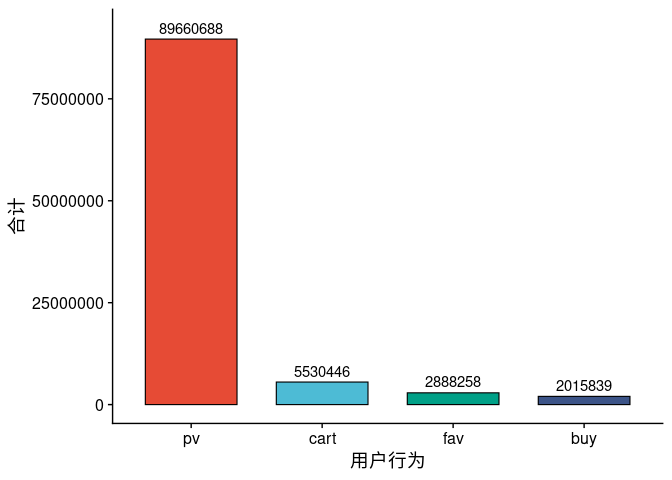

### 3.2 每日趋势

每日数据概览表

| date | uv | pv | cart | fav | buy | 人均pv | 转化率(%) |
| --- | --- | --- | --- | --- | --- | --- | --- |
| 2017-11-25 | 706641 | 9353423 | 563376 | 302071 | 201145 | 13.24 | 2.15% |
| 2017-11-26 | 715516 | 9567423 | 582581 | 308954 | 205644 | 13.37 | 2.15% |
| 2017-11-27 | 710094 | 9041187 | 541904 | 291221 | 226835 | 12.73 | 2.51% |
| 2017-11-28 | 709257 | 8842933 | 534157 | 289100 | 212000 | 12.47 | 2.4% |
| 2017-11-29 | 718922 | 9210821 | 551593 | 298587 | 223072 | 12.81 | 2.42% |
| 2017-11-30 | 730597 | 9358998 | 565015 | 302264 | 221463 | 12.81 | 2.37% |
| 2017-12-01 | 740139 | 9718959 | 623346 | 307115 | 210016 | 13.13 | 2.16% |
| 2017-12-02 | 970401 | 12329644 | 793569 | 396749 | 257907 | 12.71 | 2.09% |
| 2017-12-03 | 966977 | 12237300 | 774905 | 392197 | 257757 | 12.66 | 2.11% |

从每日的用户行为来看，休息日的访问量要明显高于工作日，但成交量却几乎不变。人均点击量几乎是一条直线，说明访问量增加是因为周末访问淘宝的用户增多了；并且由于访问量增大，成交量变化不大，转化率反而下降了不少。 画图会更直观一点：

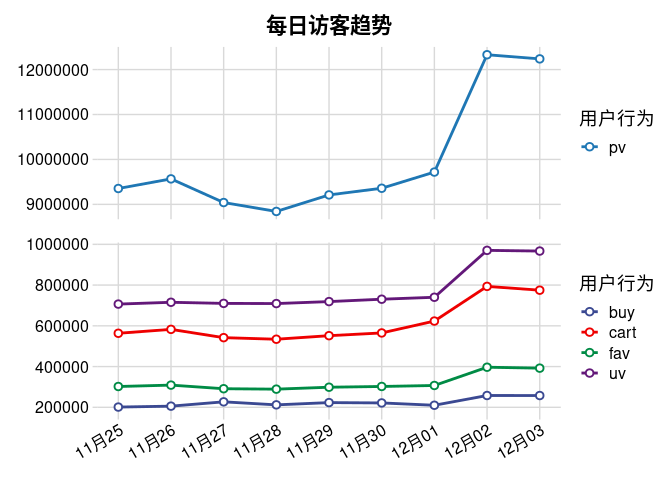

- 人均趋势

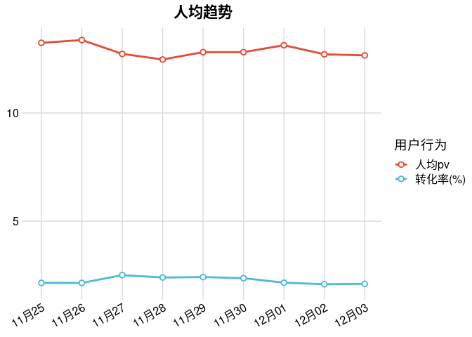

### 3.3 时间段趋势

小时数据概览表

| hour | uv | pv | cart | fav | buy | 人均pv | 转化率(%) |
| --- | --- | --- | --- | --- | --- | --- | --- |
| 00 | 318390 | 3056936 | 181807 | 105681 | 57776 | 9.60 | 1.89% |
| 01 | 167416 | 1421673 | 85412 | 51374 | 23169 | 8.49 | 1.63% |
| 02 | 98335 | 769269 | 46155 | 27791 | 12012 | 7.82 | 1.56% |
| 03 | 71415 | 524992 | 32552 | 18384 | 8026 | 7.35 | 1.53% |
| 04 | 64213 | 449628 | 28537 | 14793 | 6748 | 7.00 | 1.5% |
| 05 | 84444 | 581694 | 37264 | 18992 | 8135 | 6.89 | 1.4% |
| 06 | 179928 | 1226653 | 81305 | 40524 | 18014 | 6.82 | 1.47% |
| 07 | 329994 | 2228959 | 147046 | 74666 | 37679 | 6.75 | 1.69% |
| 08 | 444398 | 3042342 | 192036 | 103721 | 64917 | 6.85 | 2.13% |
| 09 | 520529 | 3728498 | 229890 | 127976 | 96134 | 7.16 | 2.58% |
| 10 | 577797 | 4334810 | 266963 | 147752 | 127933 | 7.50 | 2.95% |
| 11 | 587526 | 4213518 | 260831 | 145412 | 122048 | 7.17 | 2.9% |
| 12 | 593649 | 4255794 | 255811 | 140862 | 118591 | 7.17 | 2.79% |
| 13 | 602301 | 4653934 | 279829 | 150844 | 123427 | 7.73 | 2.65% |
| 14 | 593591 | 4642056 | 277093 | 148561 | 122172 | 7.82 | 2.63% |
| 15 | 603739 | 4806706 | 284269 | 151321 | 122733 | 7.96 | 2.55% |
| 16 | 598367 | 4607745 | 279035 | 148722 | 116446 | 7.70 | 2.53% |
| 17 | 585508 | 4203397 | 255342 | 137631 | 101301 | 7.18 | 2.41% |
| 18 | 583797 | 4313516 | 253193 | 133262 | 95907 | 7.39 | 2.22% |
| 19 | 624683 | 5430878 | 314774 | 161057 | 115032 | 8.69 | 2.12% |
| 20 | 663343 | 6586331 | 393209 | 191406 | 133863 | 9.93 | 2.03% |
| 21 | 682751 | 7538383 | 465924 | 219974 | 145433 | 11.04 | 1.93% |
| 22 | 649704 | 7443073 | 486249 | 232222 | 138268 | 11.46 | 1.86% |
| 23 | 514021 | 5599903 | 395920 | 195330 | 100075 | 10.89 | 1.79% |

- 每小时访客趋势：

从下图可以看出，用户的浏览和购买活动在6点左右开始升高，说明这个点以后大家都开始起床了；上午10点到下午6点流量保持稳定，这段时间是工作和学习时间；下午6点以后流量流量开始蠢蠢欲动，直到晚上9-10点达到最高峰，看来大家都喜欢睡前逛淘宝。但转化率在白天比较高，到了晚上由于访问量激增但成交量增加有限，使得转化率变得很低。但为什么10点左右的转化率这么高呢，搞不懂。

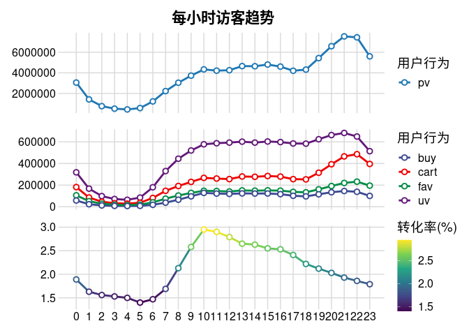

### 3.4 用户行为

对用户行为进行汇总，后面用来做K-means聚类。

统计一下用户的购买情况：

用户购买情况

| 用户总数 | 购买用户数 | 复购用户数 | 购买率 | 复购率 | 跳失率 |
| --- | --- | --- | --- | --- | --- |
| 987991 | 672404 | 443858 | 68.06% | 66.01% | 0.07% |

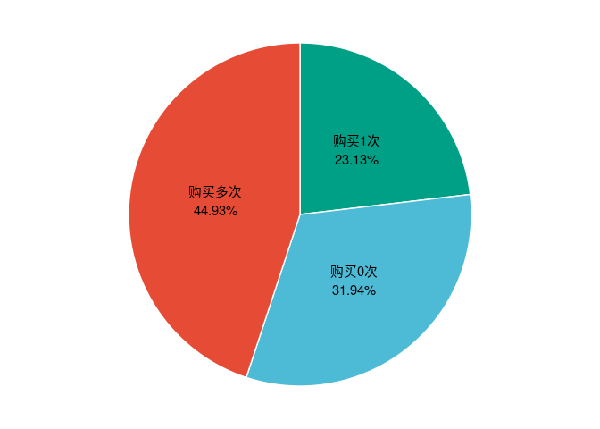

购买情况

如果在这九天内下单达到两次，你就超越了全国55.07%的淘宝用户！

### 3.5 商品类目偏好

buy可以体现哪些商品需求量大，哪些商品需求量小。提取销量top10的商品类目绘图：

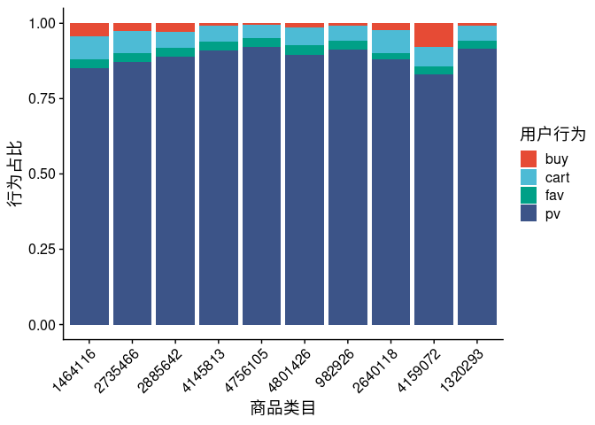

将商品类目按销量降序排列，提取销量最高的前10个类目绘制堆叠柱状图(见上图)，商品类目的销量在横轴降序排列，可以考虑加大销量占比更高类目的推送力度；对于点击量很高，但销量占比很低的类目要重新评估他们的推送价值。

## 4. 使用RFM模型和K-Means算法实现用户价值分群

### 4.1 数据预处理

统计最后一次下单距11月24日的时间间隔(R)，和下单次数(F)。

| user_id | R | F |
| --- | --- | --- |
| 2 | 8 | 7 |
| 4 | 6 | 4 |
| 11 | 1 | 1 |
| 16 | 7 | 2 |
| 17 | 7 | 1 |
| 20 | 7 | 1 |

### 4.2 训练模型

使用K-Means方法寻找聚类中心，定义超参数空间的k值范围为2-10，算法空间为：“Hartigan-Wong”, “Lloyd”, “MacQueen”；使用网格法搜索超参数空间；10折法进行超参数调整，性能度量指标选择DB指数和伪F统计量。结果如下：

```
Warning in makeTask(type, data, weights, blocking, fixup.data = fixup.data, :
Provided data is not a pure data.frame but from class tbl_df, hence it will be
converted.
```

```
Tune result:
Op. pars: centers=9; algorithm=Lloyd
db.test.mean=0.7740737,G1.test.mean=55798.9357366
```

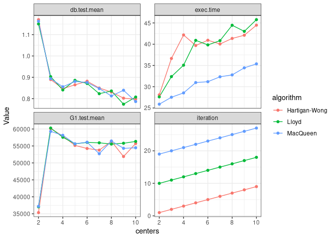

都已经聚类到10了还没有收敛，数据的时间跨度还是太短了，并且没有消费金额这一维度的数据，看来不适合K-Means聚类，还是手动打分聚类吧。

### 4.3 用户价值分析

用户指标小提琴密度图：

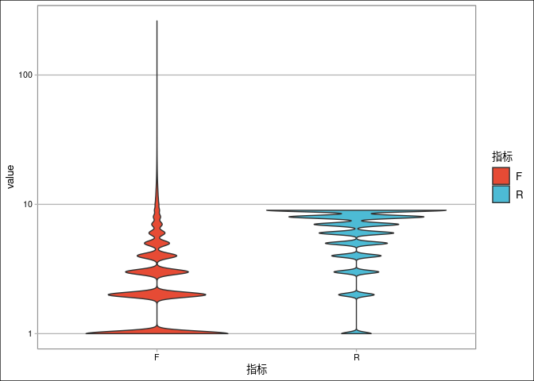

数据整体是呈现金字塔型的。

我们以上四分位数为基准对用户进行划分：

|  | R > 上四分位数 | R < 上四分位数 |
| --- | --- | --- |
| F > 上四分位数 | 重要价值用户 | 重要保持用户 |
| F < 上四分位数 | 重要发展用户 | 一般价值用户 |

统计各类用户人数：

| 用户分类 | 用户数 |
| --- | --- |
| 一般价值用户 | 388266 |
| 重要保持用户 | 98453 |
| 重要发展用户 | 110913 |
| 重要价值用户 | 74772 |

用户比例如下图所示，呈现金字塔型分布。

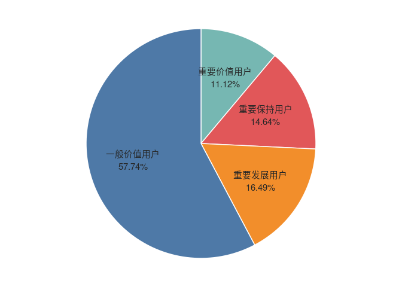

用户分类